# Technology mediation in child sexual exploitation and abuse in Africa and Asia

Population burden script

Author

Ghai et al.

# Preface

This script estimates the population-level burden of technology-facilitated child sexual exploitation and abuse (CSEA) among children aged 12-17 across 12 countries in Africa and Asia. We employ a double-denominator approach that combines:

1. **Prevalence estimates among internet-using children from the Disrupting Harms child survey**: First, we estimate prevalence across the 12 countries using the Disrupting Harm (DH) child survey (n = 11,912). Our primary outcome is the proportion of internet-using children aged 12–17 who experienced technology-facilitated CSEA through social media or gaming platforms in 2020–2021. This denominator answers: What proportion of internet-using children experience one or more forms of technology-facilitated CSEA? These estimates are design-weighted to reflect the national population of internet-using children in each country.
2. **Overall prevalence among all children (population burden)**: Second, we estimate overall prevalence among all children aged 12–17 by combining internet exposure rates with prevalence among internet using children. Internet exposure is derived from the DH household survey (approximately 1,500–10,000 households per country), which asks caregivers whether children in the household use the internet through any device or location. This provides the proportion of all 12–17-year-olds who are exposed to the online environment. We then estimate, for each country, the proportion of all children aged 12–17 who experience technology-facilitated CSEA by combining two quantities: (a) the share of children who are exposed to internet and (b) the prevalence of technology-facilitated CSEA among internet-using children.

We also provide propagate uncertainty using Monte Carlo simulation to generate 95% confidence intervals for both prevalence estimates and absolute case counts. To validate our internet exposure estimates, we compare DH-based exposure rates with International Telecommunication Union (ITU) youth internet indicators, while noting differences in age bands and reference periods. The analysis produces forest plots, scatterplots, and comparison heatmaps for visualisation.

# Libraries

```r
# Load packages
library(gtsummary)
library(dplyr)
library(tidyverse)
library(DataExplorer)
library(survey)
library(janitor)
library(rnaturalearth)
library(sf)
library(grid)
library(gridExtra)
library(png)
library(gridGraphics)
library(ggrepel)
library(officer)
library(flextable)
library(patchwork)
library(kableExtra)
library(colorspace)
library(readxl)
library(stringr)
library(readr)
library(scales)
library(glue)
library(ggtext)
library(srvyr)
library(gt)
library(cowplot)
library(grid)
```

We load processed child survey data

# Double Denominator Calculations

We now load and combine three data sources to estimate population-level prevalence: (1) DH child survey microdata providing prevalence among internet users (ocsea_df), (2) DH household denominators providing internet exposure rates and population estimates for children aged 12-17 (DH household estimates), and (3) ITU data on internet use by age and gender for validation and comparison.

## Setting Parameters and Utility Functions

We define key constants for uncertainty propagation and create helper functions for data harmonization across sources.

```r
# 3 percentage points
SE_PI_DEFAULT   <- 0.03
 # 5 percentage points
SE_PREV_DEFAULT <- 0.05
# 2020 year
TARGET_YEAR     <- 2020

# utility functions
bound01 <- function(x, eps = 1e-6) pmin(pmax(x, eps), 1 - eps)
fmt_pct <- function(x, d = 1) sprintf(paste0("%.", d, "f%%"), 100 * x)
fmt_int <- function(x) format(x, big.mark = ",", scientific = FALSE, trim = TRUE)

# function for countries name matching
harmonize_country <- function(x) {
  x <- as.character(x)
  x <- dplyr::case_match(x,
    "Viet Nam" ~ "Vietnam",
    "United Republic of Tanzania" ~ "Tanzania",
    .default = x
  )
  str_to_title(x)
}

# closest year!
pick_nearest_year <- function(df, target = TARGET_YEAR) {
  df %>%
    group_by(country) %>%
    slice_min(abs(year - target), n = 1, with_ties = FALSE) %>%
    ungroup() %>%
    select(country, year_itu = year, pi_15_24)
}
```

## Cleaning ITU Youth Exposure Data

We reshape ITU data from wide (years as columns) to long format, filter to youth aged 15-24, and select the year closest to 2020 for each country to align with DH survey timing.

```r
# load and clean ITU youth (15-24) exposure data
itu_raw <- read_csv(itu_path, show_col_types = FALSE) %>%
  clean_names()

itu_long <- itu_raw %>%
  pivot_longer(
    cols = matches("^x\\d{4}$"),
    names_to = "year",
    names_pattern = "^x(\\d{4})$",
    values_to = "value"
  ) %>%
  mutate(
    country   = harmonize_country(economy),
    year      = as.integer(year),
    is_youth  = str_detect(
      str_to_lower(disaggregation),
      "15\\s*to\\s*24|15–24|15-24"
    ),
    value_num = suppressWarnings(readr::parse_number(as.character(value))),
    exposure  = if_else(value_num > 1, value_num / 100, value_num)
  ) %>%
  filter(
    is_youth,
    !is.na(country),
    !is.na(year),
    !is.na(exposure)
  ) %>%
  transmute(
    country,
    year,
    pi_15_24 = bound01(exposure)
  ) %>%
  arrange(country, year)

itu_youth_2020 <- pick_nearest_year(itu_long, TARGET_YEAR)
```

## Processing DH Household Denominators

We extract internet exposure rates for children aged 12-17 from household survey data. Where possible, we calculate standard errors from survey counts; otherwise we flag countries requiring default SE values in uncertainty propagation.

```r
# load dh household denominators
dh_raw <- read_excel(dh_path) %>%
  clean_names() %>%
  mutate(country = harmonize_country(country))

# convert numeric columns
numeric_cols <- c(
  "with_internet",
  "no_internet",
  "total",
  "population_estimate_12_17_yr_olds_2020",
  "number_without_internet_access",
  "population_estimate_15_year_olds",
  "no_internet_15"
)

numeric_cols <- intersect(numeric_cols, names(dh_raw))
dh_raw[numeric_cols] <- lapply(dh_raw[numeric_cols], as.numeric)

# calculate internet exposure and standard errors
df_denoms <- dh_raw %>%
  mutate(
    # check with_internet a proportion or a count
    is_proportion = !is.na(with_internet) & with_internet <= 1,
    is_count      = !is.na(with_internet) & with_internet > 1,

    # exposure from counts
    exposure_from_counts = if_else(
      is_count & !is.na(total) & total > 0,
      with_internet / total,
      NA_real_
    ),

    se_from_counts = if_else(
      is_count & !is.na(total) & total > 0,
      sqrt(exposure_from_counts * (1 - exposure_from_counts) / total),
      NA_real_
    ),

    # exposure from proportions
    exposure_from_proportion = if_else(is_proportion, with_internet, NA_real_),

    exposure_from_no_internet = if_else(
      !is.na(no_internet) & no_internet <= 1,
      1 - no_internet,
      NA_real_
    ),

    exposure_from_population = if_else(
      !is.na(population_estimate_12_17_yr_olds_2020) &
        population_estimate_12_17_yr_olds_2020 > 0 &
        !is.na(number_without_internet_access),
      1 - (number_without_internet_access / population_estimate_12_17_yr_olds_2020),
      NA_real_
    ),

    # counts, then proportion
    # then no_internet, then population
    pi_12_17 = bound01(coalesce(
      exposure_from_counts,
      exposure_from_proportion,
      exposure_from_no_internet,
      exposure_from_population
    )),

    # se only available from survey counts (capped at 0.05)
    se_pi = if_else(!is.na(se_from_counts), pmin(se_from_counts, 0.05), NA_real_),

    N_12_17 = population_estimate_12_17_yr_olds_2020
  ) %>%
  select(country, pi_12_17, N_12_17, se_pi) %>%
  distinct() %>%
  group_by(country) %>%
  slice(1) %>%
  ungroup()

df_denoms
```

```
# A tibble: 13 × 4
   country     pi_12_17    N_12_17 se_pi
   <chr>          <dbl>      <dbl> <dbl>
 1 Cambodia        0.81   1819679     NA
 2 Ethiopia        0.25  16680781     NA
 3 Indonesia       0.92  27231704     NA
 4 Kenya           0.67   7539254     NA
 5 Malaysia        0.94   3178610.    NA
 6 Mozambique      0.56   4381428.    NA
 7 Namibia         0.81    294899     NA
 8 Philippines     0.95  13190360.    NA
 9 Tanzania        0.67   8813838     NA
10 Thailand        0.92   4922710.    NA
11 Total           0.81 103294723     NA
12 Uganda          0.4    6819466.    NA
13 Vietnam         0.89   8421996.    NA
```

## Calculating Prevalence Among Internet Users

We use DH child survey microdata to estimate technology-facilitated CSEA prevalence among internet-using children in 12 countries. We calculate effective sample sizes using Kish’s method to account for survey weights, then derive standard errors for uncertainty propagation.

```r
# calculate prevalence among internet users from child survey
prevalence_internet <- d_victim %>%
  mutate(country = harmonize_country(as.character(COUNTRY))) %>%
  group_by(country) %>%
  summarise(
    total_weighted   = sum(wgt_scaled, na.rm = TRUE),
    victims_weighted = sum(wgt_scaled * (victim == 1), na.rm = TRUE),
    prev_dh          = victims_weighted / total_weighted,

    # kish effective sample size
    n_effective = {
      sum_weights <- sum(wgt_scaled, na.rm = TRUE)
      sum_squared <- sum(wgt_scaled^2, na.rm = TRUE)
      if_else(
        is.finite(sum_squared) & sum_squared > 0,
        sum_weights^2 / sum_squared,
        NA_real_
      )
    },

    se_prev = if_else(
      is.finite(n_effective) & n_effective > 0,
      sqrt(prev_dh * (1 - prev_dh) / n_effective),
      NA_real_
    ),
    .groups = "drop"
  ) %>%
  mutate(
    is_edge = (prev_dh %in% c(0, 1)) & (is.na(se_prev) | se_prev == 0),
    prev_dh = if_else(is_edge, bound01(prev_dh, 1e-6), prev_dh),
    se_prev = if_else(is_edge, NA_real_, se_prev)
  ) %>%
  select(-is_edge)

# combine prevalence and exposure data
base <- prevalence_internet %>%
  inner_join(df_denoms, by = "country") %>%
  mutate(
    pi_12_17    = bound01(pi_12_17),
    prev_ALL    = prev_dh * pi_12_17,
    victims_ALL = prev_ALL * N_12_17
  )
```

## Checking Standard Error Availability

We assess how many countries have calculable standard errors versus those requiring defaults, informing our conservative uncertainty propagation approach.

```r
# exposure ses
exposure_summary <- df_denoms %>%
  summarise(
    countries   = n(),
    with_se     = sum(!is.na(se_pi)),
    missing_se  = sum(is.na(se_pi)),
    pct_with_se = round(100 * with_se / countries, 1)
  )
exposure_summary # 13 includes row total
```

```
# A tibble: 1 × 4
  countries with_se missing_se pct_with_se
      <int>   <int>      <int>       <dbl>
1        13       0         13           0
```

```r
# prevalence ses
prevalence_summary <- prevalence_internet %>%
  summarise(
    countries   = n(),
    with_se     = sum(!is.na(se_prev)),
    missing_se  = sum(is.na(se_prev)),
    pct_with_se = round(100 * with_se / countries, 1)
  )

prevalence_summary
```

```
# A tibble: 1 × 4
  countries with_se missing_se pct_with_se
      <int>   <int>      <int>       <dbl>
1        12      12          0         100
```

```r
# combined check
combined_summary <- prevalence_internet %>%
  select(country, se_prev) %>%
  left_join(
    df_denoms %>% select(country, se_pi),
    by = "country"
  ) %>%
  summarise(
    countries      = n(),
    both_calculated = sum(!is.na(se_prev) & !is.na(se_pi)),
    any_default     = sum(is.na(se_prev) | is.na(se_pi))
  )

combined_summary
```

```
# A tibble: 1 × 3
  countries both_calculated any_default
      <int>           <int>       <int>
1        12               0          12
```

## Uncertainty Propagation for Population Prevalence Estimates

We calculate population-level prevalence by combining prevalence among internet users (child survey) with internet exposure (household survey). Overall prevalence equals prevalence among users multiplied by internet exposure (P_overall = P_users × P_exposure). We propagate uncertainty from both components using Monte Carlo simulation to produce 95% confidence intervals for overall prevalence and estimated counts. For countries missing standard errors, we apply conservative defaults exceeding the 75th percentile of observed values. These defaults affect confidence interval width only, not point estimates. We treat child and household surveys as statistically independent given their separate sampling frames and field operations.

**Monte Carlo approach:** 1. For each country, we generate 5,000 random draws from the sampling distribution of each component. 2. We assume approximate normality on the logit scale:  
- Mean = point estimate (logit-transformed)  
- SD = survey-design standard error (or conservative default) transformed to the logit scale using the delta method. 3. Each draw is inverse-logit transformed: probability = exp(logit) / (1 + exp(logit)). 4. We bound all probabilities away from 0 and 1 (e.g. between 10⁻⁶ and 1 − 10⁻⁶) to avoid extreme-value instability. 5. Overall prevalence for each draw = (exposure draw) × (prevalence draw). 6. 95% CI = 2.5th and 97.5th percentiles across 5,000 draws.

Rationale for our approach: (1) Logit transformation: standard approach for bounded proportions (0–1), though less accurate at extreme values. (2) Independence assumption: we treat child and household surveys as statistically independent given their separate sampling frames, respondents, and field operations. This is appropriate for sampling error but may underestimate uncertainty from shared geographic clustering. (3) Fixed population counts: national population estimates (UN World Population Prospects year 2020) treated as known constants. (4) Conservative defaults: for settings where standard errors cannot be calculated directly, we use conservative default SEs (5 percentage points for prevalence among users and 3 percentage points for internet exposure) to avoid false precision.

Point estimates of overall prevalence are calculated as direct products (exposure × prevalence among users) and do not depend on the Monte Carlo simulation or default SE assumptions: these affect only confidence interval widths.

```r
propagate_burden <- function(est_child, df_denoms, n_draws = 5000,
                             se_prev_default     = SE_PREV_DEFAULT,
                             se_exposure_default = SE_PI_DEFAULT,
                             eps = 1e-6, se_floor = 1e-4, seed = 123) {
  set.seed(seed)

  # prepare data
  dat <- est_child %>%
    inner_join(df_denoms, by = "country") %>%
    mutate(
      prev_users = pmax(pmin(prev_dh,   1 - eps), eps),
      exposure   = pmax(pmin(pi_12_17,  1 - eps), eps),
      se_prev     = pmax(coalesce(se_prev, se_prev_default), se_floor),
      se_exposure = pmax(coalesce(se_pi,   se_exposure_default), se_floor),
      overall_point = prev_users * exposure,
      logit_prev     = qlogis(prev_users),
      logit_exposure = qlogis(exposure),
      se_logit_prev     = se_prev     / (prev_users * (1 - prev_users)),
      se_logit_exposure = se_exposure / (exposure   * (1 - exposure))
    )

  n_countries   <- nrow(dat)
  overall_lower <- numeric(n_countries)
  overall_upper <- numeric(n_countries)

  # store all draws for total CI
  all_victim_draws <- matrix(0, nrow = n_draws, ncol = n_countries)

  for (i in seq_len(n_countries)) {
    draws_prev     <- plogis(rnorm(n_draws, dat$logit_prev[i],     dat$se_logit_prev[i]))
    draws_exposure <- plogis(rnorm(n_draws, dat$logit_exposure[i], dat$se_logit_exposure[i]))
    draws_overall  <- draws_prev * draws_exposure

    overall_lower[i] <- quantile(draws_overall, 0.025, na.rm = TRUE)
    overall_upper[i] <- quantile(draws_overall, 0.975, na.rm = TRUE)

    # store victim draws for each country
    all_victim_draws[, i] <- draws_overall * dat$N_12_17[i]
  }

  # total CI by summing draws across countries
  total_draws <- rowSums(all_victim_draws, na.rm = TRUE)

  country_results <- dat %>%
    mutate(
      overall_lower = overall_lower,
      overall_upper = overall_upper,
      victims_point = N_12_17 * overall_point,
      victims_lower = N_12_17 * overall_lower,
      victims_upper = N_12_17 * overall_upper
    ) %>%
    select(
      country, prev_dh, pi_12_17, N_12_17,
      overall_point, overall_lower, overall_upper,
      victims_point, victims_lower, victims_upper
    )

  # return both country results and total draws
  list(
    country_results = country_results,
    total_draws     = total_draws
  )
}

# run burden estimates
burden_output <- propagate_burden(
  prevalence_internet,
  df_denoms,
  n_draws = 5000,
  seed    = 123
)

# extract country-level results
burden_ci <- burden_output$country_results
```

```r
# summary table
burden_table <- burden_ci %>%
  transmute(
    country                     = country,
    `Prevalence among users`    = fmt_pct(prev_dh, 1),
    `Internet exposure (12–17)` = fmt_pct(pi_12_17, 1),
    `Overall prevalence`        = sprintf(
      "%s (%s–%s)",
      fmt_pct(overall_point, 1),
      fmt_pct(overall_lower, 1),
      fmt_pct(overall_upper, 1)
    ),
    `Estimated victims`         = sprintf(
      "%s (%s–%s)",
      fmt_int(victims_point),
      fmt_int(victims_lower),
      fmt_int(victims_upper)
    ),
    `Population 12–17`          = fmt_int(N_12_17)
  ) %>%
  arrange(country)

kable(burden_table, format = "html", escape = TRUE)
```

| country | Prevalence among users | Internet exposure (12–17) | Overall prevalence | Estimated victims | Population 12–17 |
| --- | --- | --- | --- | --- | --- |
| Cambodia | 14.7% | 81.0% | 11.9% (9.9%–14.1%) | 215,961.65 (179,843.47–256,539.4) | 1,819,679 |
| Ethiopia | 18.6% | 25.0% | 4.6% (3.5%–6.1%) | 775,525.52 (581,437.27–1,018,510.2) | 16,680,781 |
| Indonesia | 6.6% | 92.0% | 6.1% (4.6%–7.9%) | 1,665,768.76 (1,250,026.87–2,150,872.1) | 27,231,704 |
| Kenya | 21.7% | 67.0% | 14.5% (12.4%–16.8%) | 1,096,162.86 (932,412.82–1,269,843.2) | 7,539,254 |
| Malaysia | 10.2% | 94.0% | 9.6% (7.6%–12.0%) | 306,233.80 (241,236.00–380,807.4) | 3,178,610 |
| Mozambique | 25.9% | 56.0% | 14.5% (12.3%–17.0%) | 634,331.27 (536,933.55–744,858.3) | 4,381,428 |
| Namibia | 20.0% | 81.0% | 16.2% (13.6%–18.9%) | 47,686.27 (40,171.88–55,612.0) | 294,899 |
| Philippines | 28.6% | 95.0% | 27.1% (23.1%–30.6%) | 3,580,485.45 (3,043,351.23–4,035,758.9) | 13,190,360 |
| Tanzania | 7.7% | 67.0% | 5.2% (4.0%–6.7%) | 456,273.59 (353,053.07–589,653.1) | 8,813,838 |
| Thailand | 17.0% | 92.0% | 15.6% (13.0%–18.2%) | 769,133.08 (642,336.03–896,437.3) | 4,922,710 |
| Uganda | 27.7% | 40.0% | 11.1% (9.1%–13.3%) | 755,631.97 (623,495.94–907,413.3) | 6,819,466 |
| Vietnam | 5.5% | 89.0% | 4.9% (3.6%–6.5%) | 410,438.22 (300,307.31–548,993.6) | 8,421,996 |

## Total Estimated Victims Across DH Countries

We sum country-level estimates to produce regional totals with propagated uncertainty intervals.

```r
# correct total using summed draws
total_victims <- list(
  point = sum(burden_ci$victims_point, na.rm = TRUE),
  lower = quantile(burden_output$total_draws, 0.025),
  upper = quantile(burden_output$total_draws, 0.975)
)

total_CSEA <- sprintf(
  "%s (%s–%s)",
  fmt_int(total_victims$point),
  fmt_int(total_victims$lower),
  fmt_int(total_victims$upper)
)
total_CSEA
```

```
[1] "10,713,632 (9,924,786–11,495,650)"
```

## Forest Plots: Country-Level Prevalence and Population Burden

We present country-specific estimates of overall prevalence (as percentages) and estimated numbers of affected children with 95% confidence intervals to facilitate cross-country comparison.

```
`height` was translated to `width`.
`height` was translated to `width`.
```

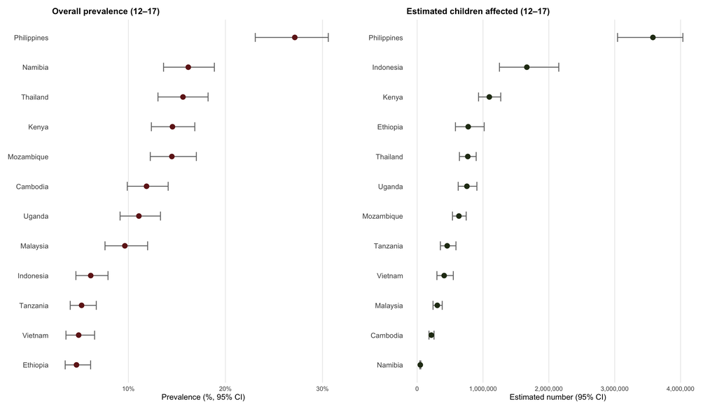

Country-level prevalence and burden of technology-facilitated CSEA (ages 12–17). Left: estimated overall prevalence among all 12–17-year-olds (% with 95% CIs). Right: estimated number of affected children (95% CIs). For each country, overall prevalence is computed as the product of (a) prevalence among internet-using children (DH child survey) and (b) the proportion of all 12–17-year-olds who use the internet (DH household survey). Counts equal overall prevalence × national 12–17 population (UN WPP 2022, year 2020). Uncertainty is propagated via parametric Monte Carlo on the logit scale (5,000 draws per country); population counts are treated as fixed. Countries are ordered separately within each panel by the point estimate.

```r
# prevalence data
prev_data <- burden_ci %>%
  mutate(
    prevalence = overall_point * 100,
    lower      = overall_lower * 100,
    upper      = overall_upper * 100
  ) %>%
  arrange(overall_point) %>%
  mutate(country = factor(country, levels = country))

# prevalence plot
p_prev <- ggplot(prev_data, aes(y = country, x = prevalence)) +
  geom_errorbarh(
    aes(xmin = lower, xmax = upper),
    height    = 0.3,
    linewidth = 0.6,
    color     = "grey45"
  ) +
  geom_point(size = 3, color = "#6f1d1b") +
  scale_x_continuous(
    labels = label_percent(scale = 1),
    expand = expansion(mult = c(0.05, 0.1))
  ) +
  labs(
    title = "Overall prevalence (12–17)",
    x     = "Prevalence (%, 95% CI)",
    y     = NULL
  ) +
  theme_minimal(base_size = 11) +
  theme(
    panel.grid.minor   = element_blank(),
    panel.grid.major.y = element_blank(),
    plot.title         = element_text(face = "bold", size = 12),
    axis.text.y        = element_text(size = 10)
  )

# count data
count_data <- burden_ci %>%
  arrange(victims_point) %>%
  mutate(country = factor(country, levels = country))

# count plot
p_count <- ggplot(count_data, aes(y = country, x = victims_point)) +
  geom_errorbarh(
    aes(xmin = victims_lower, xmax = victims_upper),
    height    = 0.3,
    linewidth = 0.6,
    color     = "grey45"
  ) +
  geom_point(size = 3, color = "#283618") +
  scale_x_continuous(
    labels = label_number(big.mark = ","),
    expand = expansion(mult = c(0.05, 0.1))
  ) +
  labs(
    title = "Estimated children affected (12–17)",
    x     = "Estimated number (95% CI)",
    y     = NULL
  ) +
  theme_minimal(base_size = 11) +
  theme(
    panel.grid.minor   = element_blank(),
    panel.grid.major.y = element_blank(),
    plot.title         = element_text(face = "bold", size = 12),
    axis.text.y        = element_text(size = 10)
  )

# combine plots
combined_forest <- p_prev | p_count
combined_forest
```

```r
ggsave(
  "forest_combined.png",
  combined_forest,
  width  = 14,
  height = 8,
  dpi    = 600,
  bg     = "white"
)
```

```
`height` was translated to `width`.
`height` was translated to `width`.
```

## Scatterplot: Prevalence vs Exposure Relationship

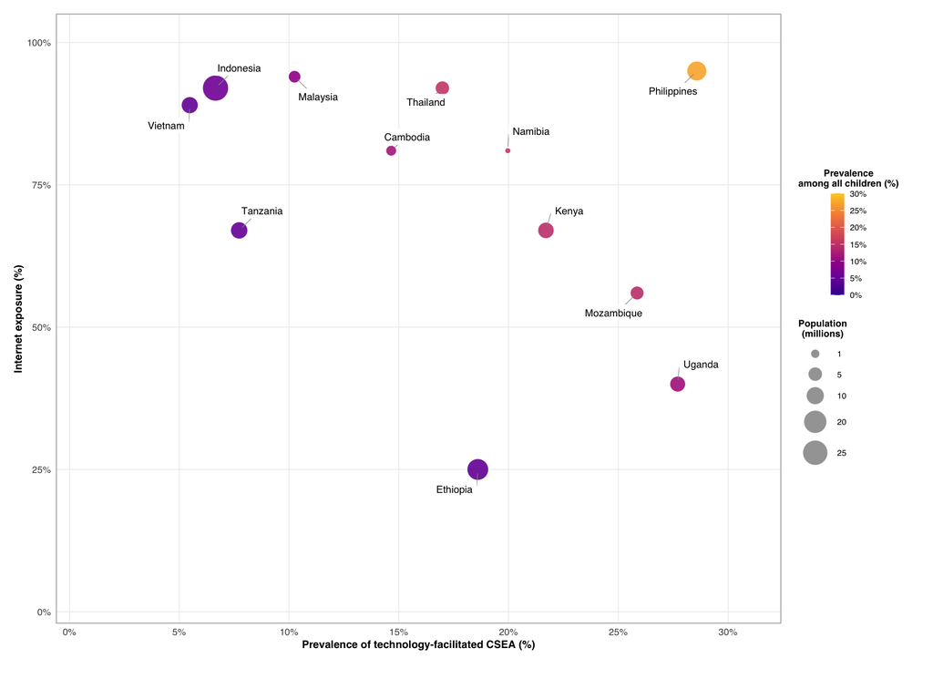

Relationship between prevalence of technology facilitated CSEA among internet users, internet exposure, and estimated overall prevalence. Scatter plot with point size proportional to population showing prevalence among internet-using 12–17-year-olds who reported one or more forms of technology-facilitated CSEA (x-axis) versus internet-exposure among all 12–17-year-olds (y-axis), across 12 countries. Colour denotes overall prevalence among all children (the product of the x- and y-axis values); bubble size denotes the 12–17 population (millions). Estimates are survey-weighted. Data sources: Disrupting Harm child and household surveys (2020–2021) and UN World Population Prospects 2022 (2020 population estimates)..

```r
plot_relationship <- function(base_df) {

  df <- base_df %>%
    mutate(
      pIU        = 100 * prev_dh,     # prevalence among users
      pi         = 100 * pi_12_17,    # exposure
      pALL       = 100 * prev_ALL,    # overall prevalence (all children)
      N_millions = N_12_17 / 1e6
    )

  ggplot(df, aes(x = pIU, y = pi)) +
    geom_point(
      aes(fill = pALL, size = N_millions),
      shape = 21,
      color = "white",
      stroke = 0.6,
      alpha  = 0.9
    ) +
    ggrepel::geom_label_repel(
      aes(label = country),
      size              = 3,
      family            = "sans",
      box.padding       = 0.6,
      point.padding     = 0.4,
      force             = 8,
      force_pull        = 0.5,
      max.overlaps      = Inf,
      seed              = 42,
      min.segment.length = 0,
      segment.color     = "grey60",
      segment.size      = 0.25,
      label.size        = 0,
      fill              = scales::alpha("white", 0.9)
    ) +
    scale_x_continuous(
      "Prevalence of technology-facilitated CSEA (%)",
      limits = c(0, 30),
      breaks = seq(0, 30, 5),
      labels = label_percent(scale = 1),
      expand = expansion(mult = c(0.02, 0.08))
    ) +
    scale_y_continuous(
      "Internet exposure (%)",
      labels = label_percent(scale = 1),
      limits = c(0, 100),
      expand = expansion(mult = c(0.02, 0.05))
    ) +
    scale_fill_viridis_c(
      "Prevalence\namong all children (%)",
      option  = "plasma",
      begin   = 0.1,
      end     = 0.9,
      limits  = c(0, 30),
      breaks  = seq(0, 30, 5),
      labels  = label_percent(scale = 1),
      oob     = scales::squish,
      guide   = guide_colorbar(
        barwidth      = 0.8,
        barheight     = 6,
        title.position = "top",
        title.hjust   = 0.5
      )
    ) +
    scale_size_continuous(
      "Population\n(millions)",
      range  = c(2, 10),
      breaks = c(1, 5, 10, 20, 25),
      guide  = guide_legend(
        title.position = "top",
        title.hjust    = 0.5,
        override.aes   = list(fill = "grey60", color = "white")
      )
    ) +
    coord_cartesian(
      clip = "off",
      xlim = c(0, NA),
      ylim = c(0, 100)
    ) +
    theme_minimal(base_size = 10, base_family = "sans") +
  theme(
    panel.grid.minor = element_blank(),
    panel.grid.major = element_line(color = "grey92", linewidth = 0.3),
    panel.border     = element_rect(fill = NA, color = "grey70", linewidth = 0.4),
    axis.title       = element_text(size = 9, face = "bold", family = "sans"),
    axis.text        = element_text(size = 8, family = "sans"),
    legend.position  = "right",
    legend.title     = element_text(size = 8, face = "bold", family = "sans"),
    legend.text      = element_text(size = 7, family = "sans"),
    plot.margin      = margin(12, 24, 12, 12)
  ) +
  labs(caption = "")
}

scatter_plot <- plot_relationship(base)
scatter_plot
```

```r
ggsave(
  "Extende Data Fig.2.tif",
  scatter_plot,
  width  = 10,
  height = 7,
  dpi    = 600,
  bg     = "white",
  compression = "lzw"
)
```

## Comparative Exposure Heatmap (DH 12-17 vs ITU 15-24)

We present a side-by-side comparison of internet exposure rates from DH household surveys and ITU estimates, highlighting measurement alignment and potential age-related differences in internet access.

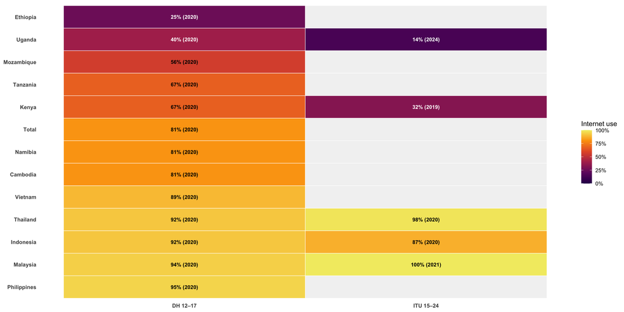

Internet exposure comparison: DH household survey vs ITU estimates

```r
exposure_heatmap <- function(df_denoms, itu_youth_2020) {

  # combine data sources
  exposure_combined <- df_denoms %>%
    select(
      country,
      dh_exposure = pi_12_17
    ) %>%
    left_join(
      itu_youth_2020 %>%
        select(
          country,
          year_itu,
          itu_exposure = pi_15_24
        ),
      by = "country"
    )

  # reshape to long format
  exposure_long <- exposure_combined %>%
    pivot_longer(
      cols = c(dh_exposure, itu_exposure),
      names_to = "source",
      values_to = "exposure"
    ) %>%
    mutate(
      source = recode(
        source,
        dh_exposure  = "DH 12–17",
        itu_exposure = "ITU 15–24"
      ),
      year = if_else(source == "DH 12–17", 2020L, year_itu),
      label = if_else(
        is.na(exposure),
        "—",
        sprintf(
          "%s (%d)",
          scales::percent(exposure, accuracy = 1),
          year
        )
      )
    )

  # order countries by DH exposure
  country_order <- exposure_long %>%
    filter(source == "DH 12–17") %>%
    arrange(desc(exposure)) %>%
    pull(country)

  exposure_long <- exposure_long %>%
    mutate(
      country = factor(country, levels = country_order),
      text_col = if_else(exposure <= 0.4, "white", "black")
    )

  # heatmap
  p <- ggplot(exposure_long, aes(x = source, y = country, fill = exposure)) +
    geom_tile(color = "white", linewidth = 0.3) +
    geom_text(
      aes(label = label, colour = text_col),
      size = 3,
      fontface = "bold",
      show.legend = FALSE
    ) +
    scale_fill_viridis_c(
      option  = "inferno",
      begin   = 0.15,
      end     = 0.95,
      labels  = scales::percent,
      limits  = c(0, 1),
      na.value = "grey95",
      name    = "Internet use"
    ) +
    scale_colour_identity() +
    labs(x = NULL, y = NULL) +
    theme_minimal() +
    theme(
      panel.grid = element_blank(),
      axis.text  = element_text(face = "bold"),
      plot.title = element_text(face = "bold")
    )

  p
}

exposure_heat <- exposure_heatmap(df_denoms, itu_youth_2020)
exposure_heat
```

```r
ggsave(
  "dh_itu.pdf",
  exposure_heat,
  width  = 14,
  height = 9,
  dpi    = 600
)
```

## Scatter Plots: DH vs ITU Exposure Estimates

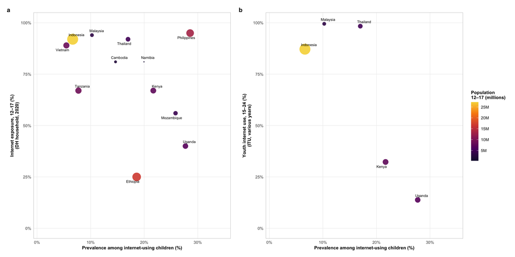

Technology-facilitated CSEA prevalence vs internet exposure

```r
dh_itu_comparison <- function(base_df, itu_youth_2020) {

  # dh data
  dh_data <- base_df %>%
    transmute(
      country,
      prevalence   = 100 * prev_dh,
      exposure_dh  = 100 * pi_12_17,
      population   = N_12_17
    ) %>%
    drop_na(prevalence, exposure_dh)

  # itu data
  itu_data <- base_df %>%
    transmute(
      country,
      prevalence = 100 * prev_dh,
      population = N_12_17
    ) %>%
    left_join(
      itu_youth_2020 %>%
        select(country, exposure_itu = pi_15_24, year_itu),
      by = "country"
    ) %>%
    mutate(exposure_itu = 100 * exposure_itu)

  scatter_theme <- theme_minimal(base_size = 10) +
    theme(
      panel.grid.minor = element_blank(),
      panel.grid.major = element_line(color = "grey92", linewidth = 0.3),
      panel.border     = element_rect(fill = NA, color = "grey70", linewidth = 0.4),
      axis.title       = element_text(size = 9, face = "bold"),
      axis.text        = element_text(size = 8),
      plot.tag         = element_text(size = 12, face = "bold"),
      plot.margin      = margin(8, 8, 8, 8)
    )

  pop_breaks <- pretty(range(dh_data$population, na.rm = TRUE), n = 4)
  x_max <- max(c(dh_data$prevalence, itu_data$prevalence), na.rm = TRUE) * 1.15

  # panel a: dh household exposure
  p_dh <- ggplot(dh_data, aes(x = prevalence, y = exposure_dh,
                              size = population, fill = population)) +
    geom_point(shape = 21, color = "white", stroke = 0.5, alpha = 0.9) +
    ggrepel::geom_text_repel(
      aes(label = country),
      size         = 2.5,
      box.padding  = 0.35,
      segment.color = "grey60",
      max.overlaps = Inf,
      seed         = 42
    ) +
    scale_x_continuous(
      "Prevalence among internet-using children (%)",
      labels = label_percent(scale = 1),
      limits = c(0, x_max),
      expand = expansion(mult = c(0.02, 0.1))
    ) +
    scale_y_continuous(
      "Internet exposure, 12–17 (%)\n(DH household, 2020)",
      labels = label_percent(scale = 1),
      limits = c(0, 100)
    ) +
    scale_fill_viridis_c(
      "Population\n12–17 (millions)",
      option = "inferno",
      begin  = 0.1,
      end    = 0.90,
      breaks = pop_breaks,
      labels = label_number(scale = 1e-6, suffix = "M"),
      guide  = guide_colorbar(barwidth = 1, barheight = 8, title.position = "top")
    ) +
    scale_size_area(max_size = 10, breaks = pop_breaks, guide = "none") +
    scatter_theme +
    labs(tag = "a")

  # panel b: itu youth exposure
  p_itu <- ggplot(itu_data, aes(x = prevalence, y = exposure_itu,
                                size = population, fill = population)) +
    geom_point(shape = 21, color = "white", stroke = 0.5, alpha = 0.9, na.rm = TRUE) +
    ggrepel::geom_text_repel(
      aes(label = country),
      size         = 2.5,
      box.padding  = 0.35,
      segment.color = "grey60",
      max.overlaps = Inf,
      seed         = 42,
      na.rm        = TRUE
    ) +
    scale_x_continuous(
      "Prevalence among internet-using children (%)",
      labels = label_percent(scale = 1),
      limits = c(0, x_max),
      expand = expansion(mult = c(0.02, 0.1))
    ) +
    scale_y_continuous(
      "Youth internet use, 15–24 (%)\n(ITU, various years)",
      labels = label_percent(scale = 1),
      limits = c(0, 100)
    ) +
    scale_fill_viridis_c(
      "Population\n12–17 (millions)",
      option = "inferno",
      begin  = 0.1,
      end    = 0.90,
      breaks = pop_breaks,
      labels = label_number(scale = 1e-6, suffix = "M"),
      guide  = guide_colorbar(barwidth = 1, barheight = 8, title.position = "top")
    ) +
    scale_size_area(max_size = 10, breaks = pop_breaks, guide = "none") +
    scatter_theme +
    labs(tag = "b")

  # combine panels
  p_dh + p_itu +
    plot_layout(guides = "collect") &
    theme(
      legend.position = "right",
      legend.title    = element_text(size = 9, face = "bold"),
      legend.text     = element_text(size = 8)
    )
}

comparison <- dh_itu_comparison(base, itu_youth_2020)
comparison
```

```r
ggsave(
  "dh_itu_comparison.png",
  comparison,
  width  = 14,
  height = 7,
  dpi    = 600,
  bg     = "white"
)
```

## Three Panel Comparisons of Prevelance and Internet Exposure

We create a three-panel figure decomposing overall prevalence into its components: technology-facilitated CSEA prevalence among internet users, internet exposure rates by country, and the resulting overall population prevalence. Here we calculated the proportion of all children aged 12-17 experiencing technology-facilitated CSEA by multiplying each country’s internet penetration rate (from DH household surveys) by the prevalence among internet users.

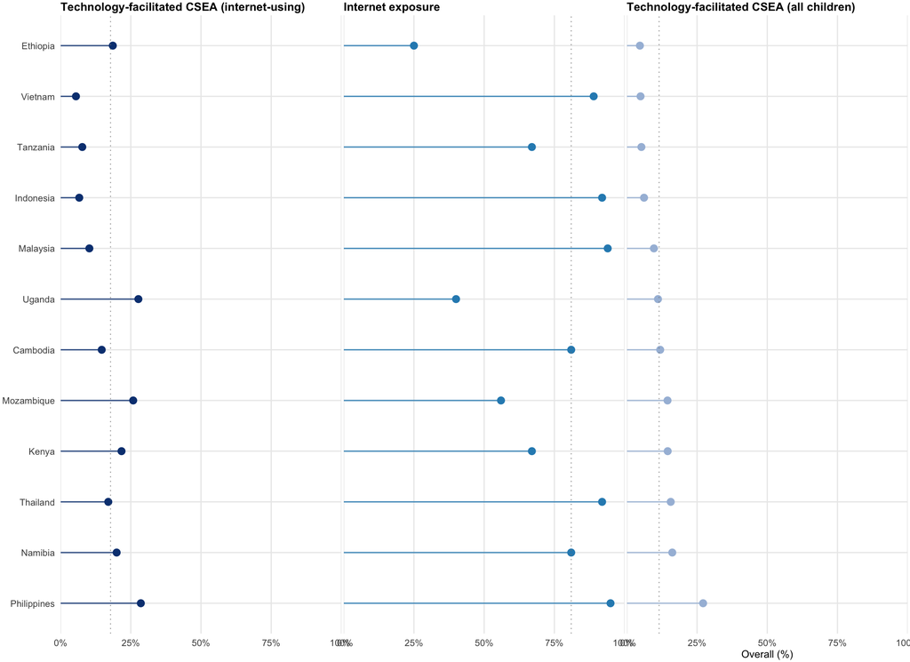

Technology-facilitated CSEA, exposure, and overall population prevalence (ages 12–17). Panel (a) shows the prevalence of technology-facilitated CSEA among internet-using 12–17-year-olds (DH child survey; survey-weighted). Panel (b) shows internet exposure from the DH household survey: the percentage of all 12–17-year-olds who use the internet. Panel (c) shows the overall prevalence among all 12–17-year-olds, conceptually computed as Panel (a) × Panel (b) for each country and year. Countries are ordered by the overall estimate in Panel (c); dashed vertical lines mark medians. (DH = Disrupting Harms.)

```r
plot_three_panel <- function(base_df) {
  # overall prevalence column
  if (!"prev_ALL" %in% names(base_df)) {
    stop("need prev_ALL in base_df")
  }

  df <- base_df

  # add percentage-scale variables
  df$pIU  <- 100 * df$prev_dh          # prevalence among users
  df$pi   <- 100 * df$pi_12_17         # exposure
  df$pALL <- 100 * df$prev_ALL         # overall prevalence

  # order by overall prevalence (descending)
  ord <- order(df$pALL, decreasing = TRUE, na.last = NA)
  df  <- df[ord, , drop = FALSE]
  df$country <- factor(df$country, levels = df$country)

  cols <- c("#084081", "#2B8CBE", "#A6BDDB")

  # clean theme
  theme_clean <- function() {
    theme_minimal(base_size = 11) +
      theme(
        panel.grid.minor      = element_blank(),
        plot.title            = element_text(face = "bold", size = 10, margin = margin(b = 2)),
        axis.title.x          = element_text(size = 9, margin = margin(t = 2)),
        axis.text.x           = element_text(size = 8, margin = margin(t = 1)),
        axis.text.y           = element_text(size = 8, margin = margin(r = 1)),
        axis.title.y          = element_blank(),
        plot.caption.position = "plot",
        plot.margin           = margin(2, 2, 2, 2)
      )
  }

  # panel constructor
  make_panel <- function(xvar, col, title, xlabel) {
    ggplot(df, aes(x = get(xvar), y = country)) +
      geom_segment(
        aes(x = 0, xend = get(xvar), yend = country),
        linewidth = 0.55,
        color     = col,
        alpha     = 0.8
      ) +
      geom_point(size = 2.6, color = col) +
      geom_vline(
        xintercept = stats::median(df[[xvar]], na.rm = TRUE),
        linetype   = 3,
        linewidth  = 0.35,
        color      = "grey50",
        alpha      = 0.8
      ) +
      scale_x_continuous(
        labels = scales::label_percent(scale = 1),
        limits = c(0, 100),
        expand = expansion(mult = c(0, 0))
      ) +
      labs(title = title, x = xlabel, y = NULL) +
      theme_clean() +
      theme(panel.spacing.x = unit(2, "pt"))
  }

  # three panels
  p1 <- make_panel("pIU",  cols[1], "Technology-facilitated CSEA (internet-using)", "Prevalence (%)")
  p2 <- make_panel("pi",   cols[2], "Internet exposure", "Share online (%)")
  p3 <- make_panel("pALL", cols[3], "Technology-facilitated CSEA (all children)", "Overall (%)")

  # x-axis titles only on bottom panel
  p1 <- p1 + theme(axis.title.x = element_blank())
  p2 <- p2 + theme(
    axis.title.x = element_blank(),
    axis.text.y  = element_blank(),
    axis.ticks.y = element_blank()
  )
  p3 <- p3 + theme(
    axis.text.y  = element_blank(),
    axis.ticks.y = element_blank()
  )

  # patchwork
  figure <- (p1 | p2 | p3) +
    patchwork::plot_layout(widths = c(1, 1, 1), guides = "collect") +
    patchwork::plot_annotation(
      theme = theme(
        plot.caption = ggtext::element_markdown(
          hjust  = 0,
          size   = 8.5,
          margin = margin(t = 2, r = 4, b = 2, l = 4)
        ),
        plot.margin = margin(2, 2, 2, 2)
      )
    )

  figure & theme(plot.margin = margin(1, 1, 1, 1))
}

three_panel <- plot_three_panel(base)
three_panel
```

```r
ggsave(
  "dh_three_panel.png",
  three_panel,
  width = 12,
  height = 8,
  dpi = 600,
  bg = "white"
)
```

## Gender-Disaggregated ITU Data and Heatmap

We visualise internet use rates by gender across study countries using ITU data, highlighting data availability and gaps in gender-disaggregated estimates.

```r
# load itu gender data
itu_gender_raw <- read_csv(itu_pathg, show_col_types = FALSE) %>%
  clean_names()

# reshape to long format
year_cols <- grep("^x\\d{4}$", names(itu_gender_raw), value = TRUE)

itu_gender_long <- itu_gender_raw %>%
  transmute(
    country = harmonize_country(economy),
    sex     = str_squish(disaggregation),
    across(all_of(year_cols), ~ parse_number(.x) / 100)
  ) %>%
  filter(sex %in% c("Male", "Female")) %>%
  pivot_longer(
    cols      = all_of(year_cols),
    names_to  = "year",
    values_to = "internet_use"
  ) %>%
  mutate(
    year = as.integer(sub("^x", "", year))
  ) %>%
  arrange(country, sex, year)

# select most recent available year
itu_gender_final <- itu_gender_long %>%
  drop_na(internet_use) %>%
  group_by(country, sex) %>%
  slice_max(year, n = 1) %>%
  ungroup() %>%
  select(country, sex, internet_use, year_itu = year)

head(itu_gender_final)
```

```
# A tibble: 6 × 4
  country           sex    internet_use year_itu
  <chr>             <chr>         <dbl>    <int>
1 Bangladesh        Female        0.373     2023
2 Bangladesh        Male          0.517     2023
3 Bhutan            Female        0.863     2021
4 Bhutan            Male          0.848     2021
5 Brunei Darussalam Female        0.998     2019
6 Brunei Darussalam Male          0.918     2019
```

```r
# filter study countries
study_countries <- c(
  "Ethiopia",
  "Kenya",
  "Mozambique",
  "Namibia",
  "Tanzania",
  "Uganda",
  "Cambodia",
  "Indonesia",
  "Malaysia",
  "Philippines",
  "Thailand",
  "Vietnam"
)

itu_study <- itu_gender_final %>%
  filter(country %in% study_countries)

# order countries by data availability
country_order <- itu_study %>%
  group_by(country) %>%
  summarise(
    n_available = n(),
    male_use    = internet_use[sex == "Male"][1],
    .groups     = "drop"
  ) %>%
  arrange(desc(n_available), desc(male_use)) %>%
  pull(country)
```

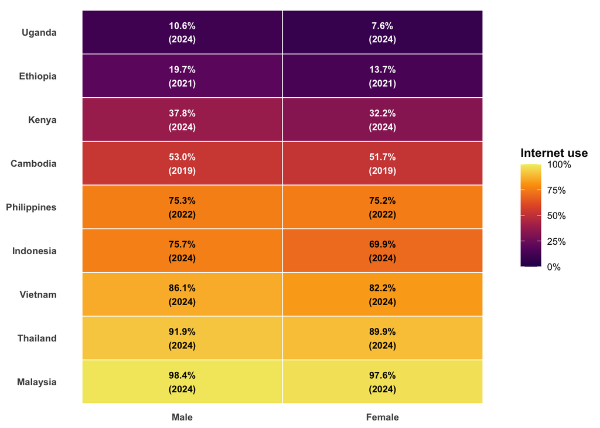

```r
# plotting data
itugender_data <- itu_study %>%
  mutate(
    country = factor(country, levels = country_order),
    sex = factor(sex, levels = c("Male", "Female")),
    label = sprintf("%.1f%%\n(%d)", internet_use * 100, year_itu)
  )

itugender_data$text_col <- ifelse(itugender_data$internet_use >= 0.6,  "black", "white")

ggplot(itugender_data, aes(x = sex, y = country, fill = internet_use)) +
  geom_tile(color = "white", linewidth = 0.3) +
  geom_text(
    aes(label = label, colour = text_col),
    size = 2.8,
    fontface = "bold",
    show.legend = FALSE
  ) +
  scale_fill_viridis_c(
    option = "inferno",
    begin = 0.15,
    end = 0.95,
    labels = percent_format(accuracy = 1),
    limits = c(0, 1),
    name = "Internet use"
  ) +
  scale_colour_identity() +
  labs(x = NULL, y = NULL) +
  theme_minimal(base_size = 10) +
  theme(
    panel.grid = element_blank(),
    axis.text.x = element_text(face = "bold"),
    axis.text.y = element_text(size = 8, face = "bold"),
    legend.title = element_text(face = "bold")
  )
```

```r
# save heatmap
ggsave(
  "itu_gender_heatmap.pdf",
  width = 6,
  height = 5,
  dpi = 600
  )
```